# Acrobat_BipedalWalker

```python
!pip -q install swig
!pip -q install "gymnasium[box2d]"
```

## Imports & Reproducibility

Imports

```python
import os
import time
import random
from collections import deque

import numpy as np
import torch
import torch.nn as nn
import torch.optim as optim
import torch.multiprocessing as mp

import gymnasium as gym
import matplotlib.pyplot as plt
```

Reproducibility

```python
# Global seed
SEED = 1227
random.seed(SEED)
np.random.seed(SEED)
torch.manual_seed(SEED)
if torch.cuda.is_available():
    torch.cuda.manual_seed_all(SEED)

# Device setup
device = torch.device("cuda" if torch.cuda.is_available() else "cpu")
print(f"Using device: {device} (SEED={SEED})")
```

```
Using device: cpu (SEED=1227)
```

Artifact directories

```python
# Base directory for all Part 3 artifacts
ARTIFACTS_ROOT = "a3_part3_artifacts"

# Environment-specific subfolders
ACROBOT_ENV_NAME = "acrobot"
BIPEDAL_ENV_NAME = "bipedal_walker"

ACROBOT_ROOT = os.path.join(ARTIFACTS_ROOT, ACROBOT_ENV_NAME)
BIPEDAL_ROOT = os.path.join(ARTIFACTS_ROOT, BIPEDAL_ENV_NAME)

# Create base folders up front
os.makedirs(ACROBOT_ROOT, exist_ok=True)
os.makedirs(BIPEDAL_ROOT, exist_ok=True)

def make_run_dir(env_root: str, run_name: str) -> str:
    """
    Create and return a directory for a specific run, e.g.
    a3_part3_artifacts/acrobot/run_1_acrobot
    """
    run_dir = os.path.join(env_root, run_name)
    os.makedirs(run_dir, exist_ok=True)

    # subfolder for videos inside each run
    video_dir = os.path.join(run_dir, "videos")
    os.makedirs(video_dir, exist_ok=True)

    return run_dir

print(f"Artifacts root: {ARTIFACTS_ROOT}")
print(f"  Acrobot dir:  {ACROBOT_ROOT}")
print(f"  Bipedal dir:  {BIPEDAL_ROOT}")
```

```
Artifacts root: a3_part3_artifacts
  Acrobot dir:  a3_part3_artifacts/acrobot
  Bipedal dir:  a3_part3_artifacts/bipedal_walker
```

## 1. Environment factories and seeding

Defines helper functions that create environments for training evaluation and video recording. Each worker receives a distinct deterministic seed so that different processes explore different trajectories while remaining reproducible. Evaluation environments use a fixed seed for consistent comparison across runs. Video environments write recordings directly into the directory for a specific run so that all artifacts for that run stay in one place.

```python
from gymnasium.wrappers import RecordVideo

def worker_seed(worker_id: int, base_seed: int = SEED) -> int:
    """
    Deterministic, distinct seed per worker/process.
    """
    return int(base_seed + 10_000 * worker_id)


def set_env_seed(env: gym.Env, seed: int):
    """
    Seed the environment RNG and local process RNGs.
    """
    obs, info = env.reset(seed=seed)
    if hasattr(env.action_space, "seed"):
        env.action_space.seed(seed)
    np.random.seed(seed)
    random.seed(seed)
    return obs, info


def make_env(env_id: str, worker_id: int = 0, base_seed: int = SEED) -> gym.Env:
    """
    Build a fresh env instance for a specific worker (actor-learner process).
    """
    env = gym.make(env_id)
    _ = set_env_seed(env, worker_seed(worker_id, base_seed))
    return env


def make_eval_env(env_id: str, base_seed: int = SEED) -> gym.Env:
    """
    Evaluation environment: deterministic seeding, no video wrapper.
    """
    env = gym.make(env_id)
    _ = set_env_seed(env, base_seed)
    return env
```

## 2. Logging and plotting

Defines helpers for tracking episode rewards and producing learning curves. The same functions will be used for Acrobot and Bipedal Walker so that plots have a consistent style. Moving average smoothing is applied to highlight the long term trend and each figure is saved into the directory for the corresponding run.

```python
def moving_average(x, window: int = 20):
    """
    Compute a simple moving average over a one dimensional array.
    """
    x = np.asarray(x, dtype=np.float32)
    if x.size == 0:
        return x
    if window <= 1:
        return x

    if x.size < window:
        return np.full_like(x, np.nan, dtype=np.float32)

    ma = np.convolve(x, np.ones(window, dtype=np.float32) / window, mode="valid")
    pad = np.full(window - 1, np.nan, dtype=np.float32)
    return np.concatenate([pad, ma])


def plot_rewards(
    rewards,
    run_dir: str,
    filename: str,
    title: str,
    ma_window: int = 20,
):
    """
    Plot episode rewards with a moving average and save the figure into run_dir.
    """
    rewards = np.asarray(rewards, dtype=np.float32)
    ma = moving_average(rewards, window=ma_window)

    plt.figure(figsize=(8, 4.5))
    plt.plot(rewards, label="Episode reward", alpha=0.4)
    plt.plot(ma, label=f"MA({ma_window})")
    plt.xlabel("Episode")
    plt.ylabel("Return")
    plt.title(title)
    plt.legend()
    plt.tight_layout()

    os.makedirs(run_dir, exist_ok=True)
    out_path = os.path.join(run_dir, filename)
    plt.savefig(out_path)
    plt.show()
    plt.close()

    print(f"Saved plot to {out_path}")
```

## 3. Actor critic networks

Defines actor critic networks that share a common feedforward torso and attach different output heads for discrete and continuous control. Subsection 3.1 builds the network for discrete action spaces such as Acrobot and subsection 3.2 will later define the variant for continuous actions used in Bipedal Walker.

### 3.1 Discrete actor critic network

Here, defines an actor critic network for discrete action spaces for Acrobot. A two layer multilayer perceptron maps the observation vector to a latent representation then a policy head outputs logits over the available actions and a value head predicts the state value. Orthogonal initialization is applied to the linear layers with a smaller gain on the policy head for more stable behaviour at the start of training and unit gain on the value head for value regression. A simple configuration dataclass stores observation dimension action count and hidden sizes so that the same architecture can be recreated for different runs. A helper constructs a categorical policy distribution from logits and a greedy action method selects the action with highest logit for deterministic evaluation.

```python
from dataclasses import dataclass
from torch.distributions import Categorical


@dataclass
class DiscreteModelConfig:
    obs_dim: int
    n_actions: int
    hidden_sizes: tuple = (256, 256)


class ActorCriticDiscrete(nn.Module):
    """
    Actor critic network for discrete action spaces.
    """

    def __init__(self, obs_dim: int, n_actions: int, hidden_sizes=(256, 256)):
        super().__init__()
        h1, h2 = hidden_sizes

        self.torso = nn.Sequential(
            nn.Linear(obs_dim, h1),
            nn.ReLU(),
            nn.Linear(h1, h2),
            nn.ReLU(),
        )
        self.policy_head = nn.Linear(h2, n_actions)
        self.value_head = nn.Linear(h2, 1)

        # Orthogonal initialization
        for m in self.modules():
            if isinstance(m, nn.Linear) and m not in (self.policy_head, self.value_head):
                nn.init.orthogonal_(m.weight, gain=nn.init.calculate_gain("relu"))
                nn.init.zeros_(m.bias)
        nn.init.orthogonal_(self.policy_head.weight, gain=0.01)
        nn.init.zeros_(self.policy_head.bias)
        nn.init.orthogonal_(self.value_head.weight, gain=1.0)
        nn.init.zeros_(self.value_head.bias)

    def forward(self, x: torch.Tensor):
        x = x.float()
        z = self.torso(x)
        logits = self.policy_head(z)
        value = self.value_head(z).squeeze(-1)
        return logits, value

    @staticmethod
    def dist_from_logits(logits: torch.Tensor) -> Categorical:
        return Categorical(logits=logits)

    @torch.no_grad()
    def greedy_action(self, obs_np: np.ndarray) -> int:
        self.eval()
        device = next(self.parameters()).device
        x = torch.tensor(obs_np, dtype=torch.float32, device=device).unsqueeze(0)
        logits, _ = self(x)
        return int(torch.argmax(logits, dim=1).item())


def build_discrete_model_from_config(cfg: DiscreteModelConfig) -> ActorCriticDiscrete:
    return ActorCriticDiscrete(cfg.obs_dim, cfg.n_actions, cfg.hidden_sizes)
```

### 3.2 Continuous actor critic network

This cell defines an actor critic network for continuous action spaces for Bipedal Walker. As in the discrete case a two layer multilayer perceptron maps the observation vector to a latent representation. A Gaussian policy head outputs the mean action vector and a trainable log standard deviation parameter while a value head predicts the state value. The same orthogonal initialization scheme is used with a smaller gain on the policy head and unit gain on the value head to stabilise optimisation. A configuration dataclass records the observation dimension action dimension and hidden sizes so that the same architecture can be reconstructed for different runs. Helper methods construct a Normal policy distribution from the mean and standard deviation and a greedy action method returns the mean action which is later clipped to the valid action range by the environment wrapper.

```python
from dataclasses import dataclass
from torch.distributions import Normal


@dataclass
class ContinuousModelConfig:
    obs_dim: int
    act_dim: int
    hidden_sizes: tuple = (256, 256)


class ActorCriticContinuous(nn.Module):
    """
    Actor critic network for continuous action spaces with a Gaussian policy.
    """

    def __init__(self, obs_dim: int, act_dim: int, hidden_sizes=(256, 256)):
        super().__init__()
        h1, h2 = hidden_sizes

        self.torso = nn.Sequential(
            nn.Linear(obs_dim, h1),
            nn.ReLU(),
            nn.Linear(h1, h2),
            nn.ReLU(),
        )
        self.mu_head = nn.Linear(h2, act_dim)
        self.value_head = nn.Linear(h2, 1)

        # Log standard deviation parameter per action dimension
        self.log_std = nn.Parameter(torch.zeros(act_dim))

        # Orthogonal initialization
        for m in self.modules():
            if isinstance(m, nn.Linear) and m not in (self.mu_head, self.value_head):
                nn.init.orthogonal_(m.weight, gain=nn.init.calculate_gain("relu"))
                nn.init.zeros_(m.bias)
        nn.init.orthogonal_(self.mu_head.weight, gain=0.01)
        nn.init.zeros_(self.mu_head.bias)
        nn.init.orthogonal_(self.value_head.weight, gain=1.0)
        nn.init.zeros_(self.value_head.bias)

    def forward(self, x: torch.Tensor):
        x = x.float()
        z = self.torso(x)
        mu = self.mu_head(z)
        value = self.value_head(z).squeeze(-1)
        std = torch.exp(self.log_std).expand_as(mu)
        return mu, std, value

    def dist_from_params(self, mu: torch.Tensor, std: torch.Tensor) -> Normal:
        return Normal(loc=mu, scale=std)

    @torch.no_grad()
    def greedy_action(self, obs_np: np.ndarray) -> np.ndarray:
        self.eval()
        device = next(self.parameters()).device
        x = torch.tensor(obs_np, dtype=torch.float32, device=device).unsqueeze(0)
        mu, std, _ = self(x)
        action = mu.squeeze(0).cpu().numpy()
        return action


def build_continuous_model_from_config(cfg: ContinuousModelConfig) -> ActorCriticContinuous:
    return ActorCriticContinuous(cfg.obs_dim, cfg.act_dim, cfg.hidden_sizes)
```

## 4. A2C loss and update helper

Defines a helper that performs one Advantage Actor Critic (A2C) update from a batch of rollout data. The function takes a model an optimizer states actions bootstrapped returns and advantages and computes the policy loss the value loss and an entropy bonus. For discrete control it uses a categorical policy distribution built from logits and for continuous control it uses a Normal policy distribution built from the mean and standard deviation. Advantages can be normalised to reduce variance. The combined loss trades off return maximisation value fit and entropy regularisation. Gradients are clipped to a maximum norm for stability then the optimizer step is applied. This helper is shared by Acrobot and Bipedal Walker and the caller only needs to specify whether the update is discrete or continuous.

```python
from typing import Dict, Literal

def a2c_update(
    model: nn.Module,
    optimizer: torch.optim.Optimizer,
    s: torch.Tensor,          # (T, obs_dim)
    a: torch.Tensor,          # (T,) for discrete or (T, act_dim) for continuous
    G: torch.Tensor,          # (T,) bootstrapped returns
    A: torch.Tensor,          # (T,) raw advantages
    *,
    control_type: Literal["discrete", "continuous"],
    normalize_adv: bool = True,
    entropy_coef: float = 0.01,
    value_coef: float = 0.5,
    max_grad_norm: float = 0.5,
) -> Dict[str, float]:
    """
    Perform one A2C update from a rollout segment. Returns scalars for logging.
    """
    model.train()

    # normalize advantages
    if normalize_adv:
        A = (A - A.mean()) / (A.std() + 1e-8)

    # Forward pass through the appropriate actor critic
    if control_type == "discrete":
        logits, values = model(s)                # ActorCriticDiscrete
        dist = model.dist_from_logits(logits)
        log_prob = dist.log_prob(a)              # (T,)
        entropy = dist.entropy().mean()
    elif control_type == "continuous":
        mu, std, values = model(s)               # ActorCriticContinuous
        dist = model.dist_from_params(mu, std)
        # Sum log prob and entropy over action dimensions
        log_prob = dist.log_prob(a).sum(dim=-1)  # (T,)
        entropy = dist.entropy().sum(dim=-1).mean()
    else:
        raise ValueError(f"Unknown control_type {control_type}")

    # Policy and value losses
    policy_loss = -(log_prob * A).mean()
    value_loss = 0.5 * (G - values).pow(2).mean()

    # Combined loss with entropy bonus
    loss = policy_loss + value_coef * value_loss - entropy_coef * entropy

    # Backward and gradient clipping
    optimizer.zero_grad()
    loss.backward()
    grad_norm = torch.nn.utils.clip_grad_norm_(model.parameters(), max_grad_norm)
    optimizer.step()

    return {
        "loss": float(loss.item()),
        "policy_loss": float(policy_loss.item()),
        "value_loss": float(value_loss.item()),
        "entropy": float(entropy.item()),
        "grad_norm": float(grad_norm if torch.is_tensor(grad_norm) else grad_norm),
    }
```

## 5. Returns and advantage computation

Defines a helper function that turns a sequence of rewards done flags and predicted state values into bootstrapped returns and advantages. The computation runs backwards in time applies the discount factor until a terminal step and uses a final bootstrap value when the rollout is truncated by the time horizon. The result is a pair of tensors for returns and advantages that can be passed directly into the A2C update helper. The same logic applies to Acrobot and Bipedal Walker so this function is shared across environments.

```python
def compute_returns_and_advantages(
    rewards: np.ndarray,
    dones: np.ndarray,
    values: torch.Tensor,
    last_value: float,
    gamma: float,
    device: torch.device,
) -> tuple[torch.Tensor, torch.Tensor]:
    """
    Compute bootstrapped returns and advantages for a single rollout.
    """
    T = len(rewards)
    returns = np.zeros(T, dtype=np.float32)
    g = float(last_value)

    for t in reversed(range(T)):
        g = rewards[t] + gamma * g * (1.0 - float(dones[t]))
        returns[t] = g

    G = torch.tensor(returns, dtype=torch.float32, device=device)
    A = G - values.detach()
    return G, A
```

## 6. Greedy evaluation helper

Defines a helper function that evaluates a trained actor critic model in greedy mode on a given environment. The function creates a fresh evaluation environment runs a fixed number of episodes selects actions using the model greedy policy and records the total reward for each episode. The same helper works for discrete and continuous control by switching on a control type argument.

```python
from typing import Literal, List


def evaluate_greedy(
    env_id: str,
    model: nn.Module,
    control_type: Literal["discrete", "continuous"],
    n_episodes: int,
    run_dir: str | None = None,
    max_steps: int | None = None,
) -> List[float]:
    """
    Run greedy evaluation episodes and return total rewards.
    """
    model.eval()
    device = next(model.parameters()).device
    returns: List[float] = []

    env = make_eval_env(env_id, base_seed=SEED)

    for ep in range(n_episodes):
        obs, info = env.reset()
        done = False
        truncated = False
        ep_return = 0.0
        steps = 0

        while not (done or truncated):
            if control_type == "discrete":
                action = model.greedy_action(obs)
            elif control_type == "continuous":
                action = model.greedy_action(obs)
            else:
                raise ValueError(f"Unknown control_type {control_type}")

            obs, reward, done, truncated, info = env.step(action)
            ep_return += float(reward)
            steps += 1

            if max_steps is not None and steps >= max_steps:
                break

        returns.append(ep_return)
        print(f"Eval episode {ep + 1} return {ep_return:.2f} steps {steps}")

    env.close()

    mean_ret = float(np.mean(returns)) if len(returns) > 0 else float("nan")
    std_ret = float(np.std(returns)) if len(returns) > 0 else float("nan")
    print(f"Greedy evaluation mean {mean_ret:.2f}  std {std_ret:.2f}")

    return returns
```

## 7. Video recording helper

Defines a helper function that runs one greedy evaluation episode in a video environment and then closes the environment. The function uses the video factory so that the recording is written into the videos subfolder of the corresponding run directory. The same logic works for discrete and continuous control by switching on a control type argument and it reuses the greedy action methods of the actor critic networks. The function returns the total reward and the number of steps for the recorded episode together.

```python
from gymnasium.wrappers import RecordVideo
from typing import Literal, Tuple


def make_video_env(env_id: str, run_dir: str, seed: int, name_prefix: str = "greedy") -> gym.Env:
    """
    Create a video environment that records into run_dir/videos.
    """
    video_dir = os.path.join(run_dir, "videos")
    os.makedirs(video_dir, exist_ok=True)

    env = gym.make(env_id, render_mode="rgb_array")
    env = RecordVideo(
        env,
        video_folder=video_dir,
        name_prefix=name_prefix,
        episode_trigger=lambda ep: True,
    )
    _ = set_env_seed(env, seed)
    return env


def record_one_greedy_episode(
    env_id: str,
    model: nn.Module,
    control_type: Literal["discrete", "continuous"],
    run_dir: str,
    max_steps: int | None = None,
) -> Tuple[float, int]:
    """
    Record one greedy episode into run_dir/videos and return total reward and step count.
    """
    model.eval()

    env = make_video_env(env_id=env_id, run_dir=run_dir, seed=SEED, name_prefix="greedy")

    obs, info = env.reset()
    done = False
    truncated = False
    ep_return = 0.0
    steps = 0

    while not (done or truncated):
        if control_type == "discrete":
            action = model.greedy_action(obs)
        elif control_type == "continuous":
            action = model.greedy_action(obs)
        else:
            raise ValueError(f"Unknown control_type {control_type}")

        obs, reward, done, truncated, info = env.step(action)
        ep_return += float(reward)
        steps += 1

        if max_steps is not None and steps >= max_steps:
            break

    env.close()
    print(
        f"Recorded greedy episode return {ep_return:.2f} "
        f"steps {steps} into {os.path.join(run_dir, 'videos')}"
    )
    return ep_return, steps
```

## 8. A2C training loop

This cell defines a training loop for the Advantage Actor Critic (A2C) algorithm that works for any single environment at a time. The function creates an environment runs rollout segments of fixed length collects states actions rewards and done flags and uses the actor critic model to predict values. After each segment it computes bootstrapped returns and advantages then applies the A2C update helper defined earlier. Episode returns are tracked in a list so that the total reward per episode can be plotted later with the shared plotting function. The control type argument switches between discrete and continuous policies so that the same loop can train Acrobot and Bipedal Walker. The function returns the trained model the list of episode returns and a small log dictionary with training metadata.

```python
from typing import Literal, Dict, Any, List


def train_a2c_single_env(
    env_id: str,
    model: nn.Module,
    control_type: Literal["discrete", "continuous"],
    run_dir: str,
    total_env_steps: int = 200_000,
    rollout_len: int = 20,
    gamma: float = 0.99,
    entropy_coef: float = 0.01,
    value_coef: float = 0.5,
    max_grad_norm: float = 0.5,
    lr: float = 7e-4,
    log_every: int = 10_000,
) -> tuple[nn.Module, List[float], Dict[str, Any]]:
    """
    Train A2C on a single environment and return model, episode returns, and logs.
    """
    os.makedirs(run_dir, exist_ok=True)

    optimizer = optim.Adam(model.parameters(), lr=lr)
    env = make_env(env_id, worker_id=0, base_seed=SEED)

    episode_returns: List[float] = []
    current_return = 0.0
    steps_total = 0
    iteration = 0
    last_log_steps = 0
    wall_start = time.time()

    obs, info = env.reset()
    done = False
    truncated = False

    while steps_total < total_env_steps:
        iteration += 1

        # Rollout buffers for this segment
        states = []
        actions = []
        rewards = []
        dones = []
        values = []

        for t in range(rollout_len):
            # Store state
            states.append(np.array(obs, copy=True))

            # Forward pass and action sampling
            obs_tensor = torch.tensor(obs, dtype=torch.float32, device=device).unsqueeze(0)

            if control_type == "discrete":
                logits, value = model(obs_tensor)
                dist = model.dist_from_logits(logits)
                action_tensor = dist.sample()
                action = int(action_tensor.item())
            elif control_type == "continuous":
                mu, std, value = model(obs_tensor)
                dist = model.dist_from_params(mu, std)
                action_tensor = dist.sample()
                action = action_tensor.squeeze(0).cpu().numpy()
            else:
                raise ValueError(f"Unknown control_type {control_type}")

            values.append(float(value.squeeze(0).item()))
            actions.append(action)

            # Environment step
            obs, reward, done, truncated, info = env.step(action)
            rewards.append(float(reward))
            dones.append(bool(done))

            current_return += float(reward)
            steps_total += 1

            # Episode boundary
            if done or truncated:
                episode_returns.append(current_return)
                current_return = 0.0
                obs, info = env.reset()
                done = False
                truncated = False

            if steps_total >= total_env_steps:
                break

        # Bootstrap value for last state if not terminal
        if done or truncated:
            last_value = 0.0
        else:
            obs_tensor = torch.tensor(obs, dtype=torch.float32, device=device).unsqueeze(0)
            with torch.no_grad():
                if control_type == "discrete":
                    _, v_last = model(obs_tensor)
                else:
                    _, _, v_last = model(obs_tensor)
            last_value = float(v_last.squeeze(0).item())

        # Prepare tensors and update
        states_tensor = torch.tensor(np.asarray(states), dtype=torch.float32, device=device)
        if control_type == "discrete":
            actions_tensor = torch.tensor(actions, dtype=torch.long, device=device)
        else:
            actions_tensor = torch.tensor(np.asarray(actions), dtype=torch.float32, device=device)

        values_tensor = torch.tensor(np.asarray(values), dtype=torch.float32, device=device)

        G, A = compute_returns_and_advantages(
            rewards=np.asarray(rewards, dtype=np.float32),
            dones=np.asarray(dones, dtype=np.bool_),
            values=values_tensor,
            last_value=last_value,
            gamma=gamma,
            device=device,
        )

        stats = a2c_update(
            model=model,
            optimizer=optimizer,
            s=states_tensor,
            a=actions_tensor,
            G=G,
            A=A,
            control_type=control_type,
            normalize_adv=True,
            entropy_coef=entropy_coef,
            value_coef=value_coef,
            max_grad_norm=max_grad_norm,
        )

        # Logging
        if iteration == 1 or (steps_total - last_log_steps) >= log_every or steps_total >= total_env_steps:
            if episode_returns:
                avg10 = float(np.mean(episode_returns[-10:]))
            else:
                avg10 = float("nan")
            print(
                f"[A2C] it={iteration:>5} steps={steps_total:>8} avg10={avg10:7.2f} "
                f"loss={stats['loss']:.3f} pg={stats['policy_loss']:.3f} "
                f"vf={stats['value_loss']:.3f} H={stats['entropy']:.3f} gn={stats['grad_norm']:.3f}",
                flush=True,
            )
            last_log_steps = steps_total

    env.close()
    wall_time = time.time() - wall_start
    if episode_returns:
        avg10 = float(np.mean(episode_returns[-10:]))
    else:
        avg10 = float("nan")
    print(f"[A2C] done steps={steps_total} time={wall_time:.1f}s avg10={avg10:.2f}")

    logs: Dict[str, Any] = {
        "episode_returns": episode_returns,
        "steps_total": steps_total,
        "wall_time_sec": wall_time,
        "train_config": {
            "env_id": env_id,
            "total_env_steps": total_env_steps,
            "rollout_len": rollout_len,
            "gamma": gamma,
            "entropy_coef": entropy_coef,
            "value_coef": value_coef,
            "max_grad_norm": max_grad_norm,
            "lr": lr,
            "log_every": log_every,
            "seed": SEED,
        },
    }
    return model, episode_returns, logs
```

## 9. Acrobot environment and configuration

The Acrobot environment creates the directory for the first Acrobot run inspects the observation and action spaces and builds a discrete actor critic model with matching dimensions using the shared configuration class and network defined earlier so that later training and evaluation steps can reuse the same model object and run folder.

```python
# Acrobot environment identifier
ACROBOT_ENV_ID = "Acrobot-v1"

# Run directory for the first Acrobot experiment
acrobot_run_name = "run_1_acrobot"
acrobot_run_dir = make_run_dir(ACROBOT_ROOT, acrobot_run_name)
print(f"Acrobot run directory: {acrobot_run_dir}")

# Inspect environment spaces to configure the model
tmp_env = gym.make(ACROBOT_ENV_ID)
print("Acrobot observation space:", tmp_env.observation_space)
print("Acrobot action space:", tmp_env.action_space)

acrobot_obs_dim = tmp_env.observation_space.shape[0]
acrobot_n_actions = tmp_env.action_space.n
tmp_env.close()

# Build discrete actor critic for Acrobot
acrobot_cfg = DiscreteModelConfig(
    obs_dim=acrobot_obs_dim,
    n_actions=acrobot_n_actions,
    hidden_sizes=(256, 256),
)
acrobot_model = build_discrete_model_from_config(acrobot_cfg).to(device)

print(
    f"Acrobot model on {device}  "
    f"obs_dim={acrobot_cfg.obs_dim}  "
    f"n_actions={acrobot_cfg.n_actions}  "
    f"hidden={acrobot_cfg.hidden_sizes}"
)
```

```
Acrobot run directory: a3_part3_artifacts/acrobot/run_1_acrobot
Acrobot observation space: Box([ -1.        -1.        -1.        -1.       -12.566371 -28.274334], [ 1.        1.        1.        1.       12.566371 28.274334], (6,), float32)
Acrobot action space: Discrete(3)
Acrobot model on cpu  obs_dim=6  n_actions=3  hidden=(256, 256)
```

## 10. Acrobot training

Trains the A2C agent on Acrobot using the shared training loop. The environment identifier, the discrete control type, and the Acrobot run directory are passed into the trainer together with the main hyperparameters such as total environment steps, rollout length, discount factor, entropy coefficient, value coefficient, gradient clipping threshold, and learning rate. The function returns the trained model the list of episode returns and a dictionary with basic training metadata. After training the code plots the episode returns using the shared plotting helper and saves the model weights into the Acrobot run directory so that evaluation and video recording can reuse the same checkpoint.

```
[A2C] it=    1 steps=      20 avg10=    nan loss=0.001 pg=-0.000 vf=0.002 H=0.000 gn=2.452
[A2C] it=  501 steps=   10020 avg10=-500.00 loss=0.101 pg=0.053 vf=0.135 H=0.640 gn=7.787
[A2C] it= 1001 steps=   20020 avg10=-494.10 loss=0.798 pg=-0.118 vf=1.880 H=0.790 gn=66.017
[A2C] it= 1501 steps=   30020 avg10=-477.30 loss=-0.238 pg=-0.314 vf=0.189 H=0.633 gn=13.735
[A2C] it= 2001 steps=   40020 avg10=-500.00 loss=-0.105 pg=-0.115 vf=0.048 H=0.457 gn=10.963
[A2C] it= 2501 steps=   50020 avg10=-473.00 loss=0.198 pg=0.154 vf=0.116 H=0.460 gn=19.529
[A2C] it= 3001 steps=   60020 avg10=-485.20 loss=-0.002 pg=-0.001 vf=0.004 H=0.095 gn=0.737
[A2C] it= 3501 steps=   70020 avg10=-242.10 loss=0.332 pg=-0.020 vf=0.740 H=0.585 gn=35.396
[A2C] it= 4001 steps=   80020 avg10=-106.70 loss=774.615 pg=-0.381 vf=1550.024 H=0.526 gn=2103.957
[A2C] it= 4501 steps=   90020 avg10= -98.00 loss=376.804 pg=-0.203 vf=754.047 H=0.525 gn=1844.157
[A2C] it= 5001 steps=  100020 avg10= -90.70 loss=147.613 pg=-0.098 vf=295.439 H=0.292 gn=866.970
[A2C] it= 5501 steps=  110020 avg10=-108.80 loss=350.043 pg=-0.206 vf=700.508 H=0.188 gn=1649.347
[A2C] it= 6001 steps=  120020 avg10= -99.70 loss=0.952 pg=-0.048 vf=2.018 H=0.292 gn=43.458
[A2C] it= 6501 steps=  130020 avg10=-104.50 loss=245.244 pg=-0.100 vf=490.703 H=0.244 gn=1481.104
[A2C] it= 7001 steps=  140020 avg10= -85.50 loss=0.134 pg=-0.123 vf=0.528 H=0.230 gn=25.203
[A2C] it= 7501 steps=  150020 avg10= -77.60 loss=357.076 pg=-0.012 vf=714.183 H=0.094 gn=1449.427
[A2C] it= 8001 steps=  160020 avg10= -81.20 loss=21.648 pg=0.002 vf=43.293 H=0.022 gn=153.847
[A2C] it= 8501 steps=  170020 avg10= -80.80 loss=0.289 pg=0.080 vf=0.423 H=0.088 gn=23.660
[A2C] it= 9001 steps=  180020 avg10= -86.50 loss=0.866 pg=-0.022 vf=1.781 H=0.087 gn=32.721
[A2C] it= 9501 steps=  190020 avg10= -84.20 loss=59.934 pg=0.000 vf=119.868 H=0.005 gn=1239.099
[A2C] it=10001 steps=  200020 avg10= -88.50 loss=9.083 pg=-0.028 vf=18.228 H=0.103 gn=110.196
[A2C] it=10501 steps=  210020 avg10= -84.60 loss=-0.062 pg=-0.122 vf=0.124 H=0.065 gn=9.656
[A2C] it=11001 steps=  220020 avg10= -84.80 loss=0.482 pg=0.013 vf=0.941 H=0.055 gn=28.361
[A2C] it=11501 steps=  230020 avg10= -81.90 loss=21.950 pg=-0.056 vf=44.016 H=0.087 gn=238.667
[A2C] it=12001 steps=  240020 avg10= -77.00 loss=-0.070 pg=-0.267 vf=0.397 H=0.042 gn=22.235
[A2C] it=12501 steps=  250020 avg10= -83.10 loss=3.630 pg=-0.090 vf=7.444 H=0.067 gn=76.175
[A2C] it=13001 steps=  260020 avg10= -92.10 loss=0.458 pg=0.009 vf=0.903 H=0.062 gn=32.937
[A2C] it=13501 steps=  270020 avg10= -77.00 loss=1.240 pg=-0.038 vf=2.566 H=0.158 gn=29.162
[A2C] it=14001 steps=  280020 avg10= -81.10 loss=48.200 pg=-0.000 vf=96.400 H=0.000 gn=891.811
[A2C] it=14501 steps=  290020 avg10= -82.00 loss=0.074 pg=-0.009 vf=0.171 H=0.061 gn=14.423
[A2C] it=15000 steps=  300000 avg10= -87.40 loss=22.177 pg=0.101 vf=44.158 H=0.084 gn=192.496
[A2C] done steps=300000 time=257.3s avg10=-87.40
```

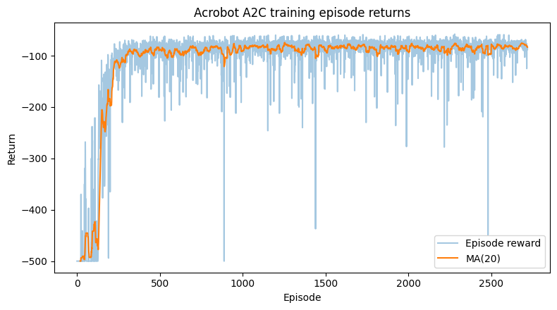

```
Saved plot to a3_part3_artifacts/acrobot/run_1_acrobot/acrobot_train_rewards.png
Saved Acrobot A2C weights to a3_part3_artifacts/acrobot/run_1_acrobot/acrobot_a2c_weights.pth
```

```python
# Main A2C hyperparameters for Acrobot
acrobot_total_steps = 300_000
acrobot_rollout_len = 20
acrobot_gamma = 0.99
acrobot_entropy_coef = 0.03
acrobot_value_coef = 0.5
acrobot_max_grad_norm = 0.5
acrobot_lr = 3e-4
acrobot_log_every = 10_000

acrobot_model, acrobot_episode_returns, acrobot_logs = train_a2c_single_env(
    env_id=ACROBOT_ENV_ID,
    model=acrobot_model,
    control_type="discrete",
    run_dir=acrobot_run_dir,
    total_env_steps=acrobot_total_steps,
    rollout_len=acrobot_rollout_len,
    gamma=acrobot_gamma,
    entropy_coef=acrobot_entropy_coef,
    value_coef=acrobot_value_coef,
    max_grad_norm=acrobot_max_grad_norm,
    lr=acrobot_lr,
    log_every=acrobot_log_every,
)

# Plot training rewards
plot_rewards(
    rewards=acrobot_episode_returns,
    run_dir=acrobot_run_dir,
    filename="acrobot_train_rewards.png",
    title="Acrobot A2C training episode returns",
    ma_window=20,
)

# Save model weights for reuse in evaluation and video recording
acrobot_weights_path = os.path.join(acrobot_run_dir, "acrobot_a2c_weights.pth")
torch.save(acrobot_model.state_dict(), acrobot_weights_path)
print(f"Saved Acrobot A2C weights to {acrobot_weights_path}")
```

## 11. Acrobot greedy evaluation

This cell evaluates the trained Acrobot agent in greedy mode using the shared evaluation and plotting helpers. A fresh evaluation environment is created the actor critic model selects greedy actions for a fixed number of episodes and the total reward per episode is recorded. The episode returns are then plotted with the common plotting function and saved into the Acrobot run directory together with the printed summary statistics.

```
Eval episode 1 return -71.00 steps 72
Eval episode 2 return -73.00 steps 74
Eval episode 3 return -77.00 steps 78
Eval episode 4 return -81.00 steps 82
Eval episode 5 return -71.00 steps 72
Eval episode 6 return -71.00 steps 72
Eval episode 7 return -77.00 steps 78
Eval episode 8 return -86.00 steps 87
Eval episode 9 return -68.00 steps 69
Eval episode 10 return -77.00 steps 78
Greedy evaluation mean -75.20  std 5.19
```

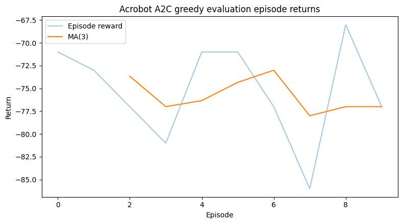

```
Saved plot to a3_part3_artifacts/acrobot/run_1_acrobot/acrobot_eval_rewards.png
Acrobot greedy evaluation returns: [-71.0, -73.0, -77.0, -81.0, -71.0, -71.0, -77.0, -86.0, -68.0, -77.0]
Mean return -75.20  Std 5.19
```

```python
# Number of greedy evaluation episodes for Acrobot
acrobot_eval_episodes = 10


if not os.path.exists(acrobot_weights_path):
    raise FileNotFoundError(f"Trained weights not found at {acrobot_weights_path}")

acrobot_model = build_discrete_model_from_config(acrobot_cfg).to(device)
acrobot_model.load_state_dict(torch.load(acrobot_weights_path, map_location=device))

# Run greedy evaluation
acrobot_eval_returns = evaluate_greedy(
    env_id=ACROBOT_ENV_ID,
    model=acrobot_model,
    control_type="discrete",
    n_episodes=acrobot_eval_episodes,
    run_dir=acrobot_run_dir,
)

# Plot evaluation rewards
plot_rewards(
    rewards=acrobot_eval_returns,
    run_dir=acrobot_run_dir,
    filename="acrobot_eval_rewards.png",
    title="Acrobot A2C greedy evaluation episode returns",
    ma_window=3,
)

print("Acrobot greedy evaluation returns:", acrobot_eval_returns)
print(f"Mean return {np.mean(acrobot_eval_returns):.2f}  Std {np.std(acrobot_eval_returns):.2f}")
```

## 12 Acrobot greedy video recording

Records a single greedy evaluation episode for the trained Acrobot agent and writes the video file into the Acrobot run directory. The same actor critic model used for evaluation selects greedy actions the environment runs until termination or time limit and the helper function reports the total reward and number of steps for the recorded episode.

```python
# Record one greedy episode for Acrobot into the run directory
acrobot_video_return, acrobot_video_steps = record_one_greedy_episode(
    env_id=ACROBOT_ENV_ID,
    model=acrobot_model,
    control_type="discrete",
    run_dir=acrobot_run_dir,
    max_steps=None,  # Acrobot internal time limit handles episode length
)

print(
    f"Acrobot video episode return {acrobot_video_return:.2f} "
    f"steps {acrobot_video_steps}"
)
```

```
Recorded greedy episode return -71.00 steps 72 into a3_part3_artifacts/acrobot/run_1_acrobot/videos
Acrobot video episode return -71.00 steps 72
```

## 13. Bipedal Walker environment and configuration

This section selects the Bipedal Walker environment creates a directory for the first Bipedal Walker run inspects the observation and action spaces and builds a continuous actor critic model with matching dimensions using the shared configuration class and network defined earlier so that later training evaluation and video recording steps can reuse the same model object and run folder.

```python
# Bipedal Walker environment identifier
BIPEDAL_ENV_ID = "BipedalWalker-v3"

# Run directory for the first Bipedal Walker experiment
bipedal_run_name = "run_1_bipedal"
bipedal_run_dir = make_run_dir(BIPEDAL_ROOT, bipedal_run_name)
print(f"Bipedal Walker run directory: {bipedal_run_dir}")

# Inspect environment spaces to configure the model
tmp_env_bw = gym.make(BIPEDAL_ENV_ID)
print("Bipedal Walker observation space:", tmp_env_bw.observation_space)
print("Bipedal Walker action space:", tmp_env_bw.action_space)

bipedal_obs_dim = tmp_env_bw.observation_space.shape[0]
bipedal_act_dim = tmp_env_bw.action_space.shape[0]
tmp_env_bw.close()

# Build continuous actor critic for Bipedal Walker
bipedal_cfg = ContinuousModelConfig(
    obs_dim=bipedal_obs_dim,
    act_dim=bipedal_act_dim,
    hidden_sizes=(256, 256),
)
bipedal_model = build_continuous_model_from_config(bipedal_cfg).to(device)

print(
    f"Bipedal Walker model on {device}  "
    f"obs_dim={bipedal_cfg.obs_dim}  "
    f"act_dim={bipedal_cfg.act_dim}  "
    f"hidden={bipedal_cfg.hidden_sizes}"
)
```

```
Bipedal Walker run directory: a3_part3_artifacts/bipedal_walker/run_1_bipedal
Bipedal Walker observation space: Box([-3.1415927 -5.        -5.        -5.        -3.1415927 -5.
 -3.1415927 -5.        -0.        -3.1415927 -5.        -3.1415927
 -5.        -0.        -1.        -1.        -1.        -1.
 -1.        -1.        -1.        -1.        -1.        -1.       ], [3.1415927 5.        5.        5.        3.1415927 5.        3.1415927
 5.        5.        3.1415927 5.        3.1415927 5.        5.
 1.        1.        1.        1.        1.        1.        1.
 1.        1.        1.       ], (24,), float32)
Bipedal Walker action space: Box(-1.0, 1.0, (4,), float32)
Bipedal Walker model on cpu  obs_dim=24  act_dim=4  hidden=(256, 256)
```

## 14 Bipedal Walker training

Trains the A2C agent on Bipedal Walker using the shared training loop. The environment identifier, the continuous control type, and the Bipedal Walker run directory are passed into the trainer together with the main hyperparameters such as total environment steps, rollout length, discount factor, entropy coefficient, value coefficient, gradient clipping threshold, and learning rate. The function returns the trained model the list of episode returns and a dictionary with basic training metadata. After training the code plots the episode returns using the shared plotting helper and saves the model weights into the Bipedal Walker run directory so that evaluation and video recording can reuse the same checkpoint.

Run#1

```
[A2C] it=    1 steps=      20 avg10=    nan loss=0.006 pg=-0.120 vf=0.480 H=5.676 gn=2.047
[A2C] it= 1001 steps=   20020 avg10=-134.24 loss=-0.895 pg=-0.784 vf=0.004 H=5.644 gn=6.725
[A2C] it= 2001 steps=   40020 avg10=-104.91 loss=-0.077 pg=0.027 vf=0.016 H=5.625 gn=3.424
[A2C] it= 3001 steps=   60020 avg10=-115.01 loss=2.063 pg=-0.223 vf=4.797 H=5.623 gn=30.053
[A2C] it= 4001 steps=   80020 avg10=-142.47 loss=-0.617 pg=-0.509 vf=0.008 H=5.633 gn=7.280
[A2C] it= 5001 steps=  100020 avg10=-118.28 loss=0.065 pg=0.170 vf=0.016 H=5.645 gn=9.282
[A2C] it= 6001 steps=  120020 avg10=-121.62 loss=0.207 pg=0.287 vf=0.066 H=5.627 gn=8.436
[A2C] it= 7001 steps=  140020 avg10=-119.37 loss=0.190 pg=0.297 vf=0.009 H=5.584 gn=6.722
[A2C] it= 8001 steps=  160020 avg10=-130.48 loss=2841.509 pg=-0.425 vf=5684.091 H=5.584 gn=6542.455
[A2C] it= 9001 steps=  180020 avg10=-114.02 loss=263.503 pg=-0.256 vf=527.742 H=5.588 gn=1034.069
[A2C] it=10001 steps=  200020 avg10=-120.17 loss=67.259 pg=0.435 vf=133.871 H=5.577 gn=653.569
[A2C] it=11001 steps=  220020 avg10=-119.36 loss=-0.367 pg=-0.260 vf=0.008 H=5.578 gn=1.400
[A2C] it=12001 steps=  240020 avg10=-111.42 loss=0.320 pg=0.102 vf=0.660 H=5.606 gn=8.705
[A2C] it=13001 steps=  260020 avg10=-112.40 loss=1.166 pg=0.413 vf=1.732 H=5.630 gn=43.504
[A2C] it=14001 steps=  280020 avg10=-113.17 loss=-0.332 pg=-0.255 vf=0.071 H=5.653 gn=5.170
[A2C] it=15001 steps=  300020 avg10=-113.38 loss=2.463 pg=0.025 vf=5.103 H=5.665 gn=70.711
[A2C] it=16001 steps=  320020 avg10=-121.98 loss=0.043 pg=-0.273 vf=0.859 H=5.689 gn=27.045
[A2C] it=17001 steps=  340020 avg10=-121.65 loss=-0.368 pg=-0.308 vf=0.106 H=5.665 gn=5.201
[A2C] it=18001 steps=  360020 avg10=-121.03 loss=7.284 pg=0.068 vf=14.659 H=5.674 gn=326.438
[A2C] it=19001 steps=  380020 avg10=-109.72 loss=0.850 pg=0.101 vf=1.726 H=5.690 gn=29.016
[A2C] it=20000 steps=  400000 avg10=-113.64 loss=-0.326 pg=-0.425 vf=0.426 H=5.694 gn=7.402
[A2C] done steps=400000 time=431.4s avg10=-113.64
```

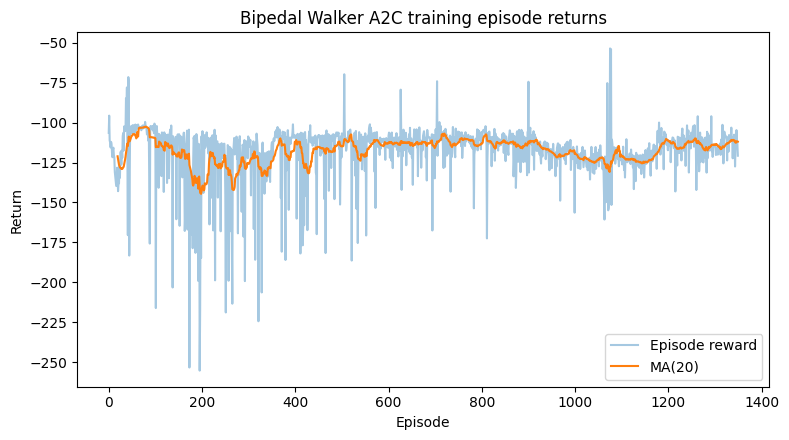

```
Saved plot to a3_part3_artifacts/bipedal_walker/run_1_bipedal/bipedal_train_rewards.png
Saved Bipedal Walker A2C weights to a3_part3_artifacts/bipedal_walker/run_1_bipedal/bipedal_a2c_weights.pth
```

```python
# Main A2C hyperparameters for Bipedal Walker
bipedal_total_steps = 400_000
bipedal_rollout_len = 20
bipedal_gamma = 0.99
bipedal_entropy_coef = 0.02
bipedal_value_coef = 0.5
bipedal_max_grad_norm = 0.5
bipedal_lr = 3e-4
bipedal_log_every = 20_000

bipedal_model, bipedal_episode_returns, bipedal_logs = train_a2c_single_env(
    env_id=BIPEDAL_ENV_ID,
    model=bipedal_model,
    control_type="continuous",
    run_dir=bipedal_run_dir,
    total_env_steps=bipedal_total_steps,
    rollout_len=bipedal_rollout_len,
    gamma=bipedal_gamma,
    entropy_coef=bipedal_entropy_coef,
    value_coef=bipedal_value_coef,
    max_grad_norm=bipedal_max_grad_norm,
    lr=bipedal_lr,
    log_every=bipedal_log_every,
)

# Plot training rewards
plot_rewards(
    rewards=bipedal_episode_returns,
    run_dir=bipedal_run_dir,
    filename="bipedal_train_rewards.png",
    title="Bipedal Walker A2C training episode returns",
    ma_window=20,
)

# Save model weights for reuse in evaluation and video recording
bipedal_weights_path = os.path.join(bipedal_run_dir, "bipedal_a2c_weights.pth")
torch.save(bipedal_model.state_dict(), bipedal_weights_path)
print(f"Saved Bipedal Walker A2C weights to {bipedal_weights_path}")
```

Run#2

```
Bipedal Walker v2 run directory: a3_part3_artifacts/bipedal_walker/run_2_bipedal
[A2C] it=    1 steps=      10 avg10=    nan loss=-0.130 pg=-0.117 vf=0.087 H=5.676 gn=2.416
[A2C] it= 2001 steps=   20010 avg10=-134.17 loss=-0.051 pg=0.002 vf=0.005 H=5.504 gn=4.917
[A2C] it= 4001 steps=   40010 avg10=-110.99 loss=-0.968 pg=-0.992 vf=0.156 H=5.415 gn=4.875
[A2C] it= 6001 steps=   60010 avg10= -99.57 loss=-0.071 pg=-0.040 vf=0.043 H=5.269 gn=3.850
[A2C] it= 8001 steps=   80010 avg10=-102.76 loss=0.934 pg=0.973 vf=0.027 H=5.218 gn=5.590
[A2C] it=10001 steps=  100010 avg10= -91.49 loss=-0.901 pg=-0.866 vf=0.032 H=5.112 gn=4.236
[A2C] it=12001 steps=  120010 avg10= -64.28 loss=0.234 pg=0.279 vf=0.010 H=5.031 gn=5.918
[A2C] it=14001 steps=  140010 avg10=-100.84 loss=2.872 pg=-0.504 vf=6.853 H=4.976 gn=67.459
[A2C] it=16001 steps=  160010 avg10=   2.13 loss=-0.313 pg=-0.358 vf=0.188 H=4.936 gn=7.850
[A2C] it=18001 steps=  180010 avg10= -15.44 loss=0.351 pg=0.360 vf=0.081 H=4.906 gn=14.354
[A2C] it=20001 steps=  200010 avg10=-104.95 loss=4.634 pg=-0.841 vf=11.049 H=4.912 gn=181.398
[A2C] it=22001 steps=  220010 avg10= -19.28 loss=-0.729 pg=-0.880 vf=0.401 H=4.924 gn=21.276
[A2C] it=24001 steps=  240010 avg10= -47.85 loss=-0.041 pg=-0.037 vf=0.092 H=4.938 gn=9.805
[A2C] it=26001 steps=  260010 avg10= -73.57 loss=1.595 pg=0.079 vf=3.131 H=4.913 gn=56.635
[A2C] it=28001 steps=  280010 avg10= -70.27 loss=10.199 pg=-0.010 vf=20.517 H=4.922 gn=248.942
[A2C] it=30001 steps=  300010 avg10=  -9.08 loss=80.174 pg=-0.613 vf=161.673 H=4.924 gn=2066.540
[A2C] it=32001 steps=  320010 avg10= -91.42 loss=-0.147 pg=-0.389 vf=0.582 H=4.937 gn=30.432
[A2C] it=34001 steps=  340010 avg10= -16.47 loss=-0.236 pg=-0.445 vf=0.518 H=4.940 gn=17.603
[A2C] it=36001 steps=  360010 avg10=-102.78 loss=9.687 pg=-0.070 vf=19.613 H=4.967 gn=366.375
[A2C] it=38001 steps=  380010 avg10=-118.12 loss=3.084 pg=-0.274 vf=6.817 H=5.025 gn=96.156
[A2C] it=40001 steps=  400010 avg10=-118.29 loss=9.340 pg=-0.104 vf=18.989 H=5.032 gn=276.955
[A2C] it=42001 steps=  420010 avg10= -42.44 loss=-1.041 pg=-1.050 vf=0.119 H=5.057 gn=10.410
[A2C] it=44001 steps=  440010 avg10=  25.53 loss=-0.482 pg=-0.467 vf=0.073 H=5.077 gn=13.111
[A2C] it=46001 steps=  460010 avg10= -76.65 loss=0.354 pg=0.092 vf=0.625 H=5.083 gn=19.809
[A2C] it=48001 steps=  480010 avg10= 139.46 loss=-0.435 pg=-0.421 vf=0.073 H=5.081 gn=13.160
[A2C] it=50001 steps=  500010 avg10= 190.80 loss=-0.633 pg=-0.662 vf=0.157 H=5.042 gn=14.412
[A2C] it=52001 steps=  520010 avg10= -62.49 loss=-0.726 pg=-0.776 vf=0.202 H=5.067 gn=14.043
[A2C] it=54001 steps=  540010 avg10=  78.68 loss=0.331 pg=0.370 vf=0.024 H=5.059 gn=10.239
[A2C] it=56001 steps=  560010 avg10=  73.95 loss=0.943 pg=0.991 vf=0.007 H=5.104 gn=11.769
[A2C] it=58001 steps=  580010 avg10= -93.24 loss=0.288 pg=0.322 vf=0.035 H=5.140 gn=12.325
[A2C] it=60000 steps=  600000 avg10= 136.22 loss=0.592 pg=0.466 vf=0.355 H=5.167 gn=22.082
[A2C] done steps=600000 time=749.7s avg10=136.22
```

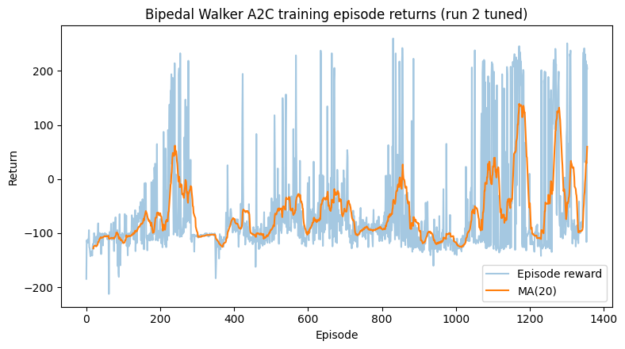

```
Saved plot to a3_part3_artifacts/bipedal_walker/run_2_bipedal/bipedal_train_rewards_v2.png
Saved Bipedal Walker A2C v2 weights to a3_part3_artifacts/bipedal_walker/run_2_bipedal/bipedal_a2c_weights_v2.pth
```

```python
# Second Bipedal Walker run with tuned hyperparameters
bipedal_run_name_v2 = "run_2_bipedal"
bipedal_run_dir_v2 = make_run_dir(BIPEDAL_ROOT, bipedal_run_name_v2)
print(f"Bipedal Walker v2 run directory: {bipedal_run_dir_v2}")

# Fresh model for the second run
bipedal_model_v2 = build_continuous_model_from_config(bipedal_cfg).to(device)

# Tuned A2C hyperparameters for Bipedal Walker
bipedal_total_steps_v2 = 600_000
bipedal_rollout_len_v2 = 10
bipedal_gamma_v2 = 0.99
bipedal_entropy_coef_v2 = 0.01
bipedal_value_coef_v2 = 0.5
bipedal_max_grad_norm_v2 = 0.3
bipedal_lr_v2 = 2.5e-4
bipedal_log_every_v2 = 20_000

bipedal_model_v2, bipedal_episode_returns_v2, bipedal_logs_v2 = train_a2c_single_env(
    env_id=BIPEDAL_ENV_ID,
    model=bipedal_model_v2,
    control_type="continuous",
    run_dir=bipedal_run_dir_v2,
    total_env_steps=bipedal_total_steps_v2,
    rollout_len=bipedal_rollout_len_v2,
    gamma=bipedal_gamma_v2,
    entropy_coef=bipedal_entropy_coef_v2,
    value_coef=bipedal_value_coef_v2,
    max_grad_norm=bipedal_max_grad_norm_v2,
    lr=bipedal_lr_v2,
    log_every=bipedal_log_every_v2,
)

# Plot training rewards for v2
plot_rewards(
    rewards=bipedal_episode_returns_v2,
    run_dir=bipedal_run_dir_v2,
    filename="bipedal_train_rewards_v2.png",
    title="Bipedal Walker A2C training episode returns (run 2 tuned)",
    ma_window=20,
)

# Save v2 model weights
bipedal_weights_path_v2 = os.path.join(bipedal_run_dir_v2, "bipedal_a2c_weights_v2.pth")
torch.save(bipedal_model_v2.state_dict(), bipedal_weights_path_v2)
print(f"Saved Bipedal Walker A2C v2 weights to {bipedal_weights_path_v2}")
```

Run#3

```
Bipedal Walker v3 run directory: a3_part3_artifacts/bipedal_walker/run_3_bipedal
[A2C] it=    1 steps=      10 avg10=    nan loss=0.209 pg=0.202 vf=0.105 H=5.676 gn=1.372
[A2C] it= 2001 steps=   20010 avg10=-105.03 loss=1.005 pg=0.646 vf=0.808 H=5.638 gn=24.849
[A2C] it= 4001 steps=   40010 avg10=-125.50 loss=36.813 pg=-0.347 vf=74.412 H=5.641 gn=152.480
[A2C] it= 6001 steps=   60010 avg10=-116.65 loss=-0.184 pg=-0.150 vf=0.021 H=5.575 gn=4.817
[A2C] it= 8001 steps=   80010 avg10=-122.56 loss=0.718 pg=0.651 vf=0.223 H=5.559 gn=8.892
[A2C] it=10001 steps=  100010 avg10= -98.50 loss=0.040 pg=0.065 vf=0.039 H=5.502 gn=3.422
[A2C] it=12001 steps=  120010 avg10=-104.46 loss=-0.654 pg=-0.618 vf=0.016 H=5.430 gn=2.737
[A2C] it=14001 steps=  140010 avg10= -60.15 loss=-0.066 pg=-0.199 vf=0.351 H=5.392 gn=5.275
[A2C] it=16001 steps=  160010 avg10=  -5.13 loss=0.630 pg=0.451 vf=0.443 H=5.329 gn=10.322
[A2C] it=18001 steps=  180010 avg10= -28.99 loss=1.917 pg=-0.632 vf=5.182 H=5.277 gn=94.941
[A2C] it=20001 steps=  200010 avg10= -30.69 loss=2.943 pg=0.081 vf=5.808 H=5.239 gn=94.495
[A2C] it=22001 steps=  220010 avg10=-115.86 loss=62.415 pg=-0.033 vf=124.980 H=5.202 gn=1420.071
[A2C] it=24001 steps=  240010 avg10=-106.71 loss=29980.359 pg=0.079 vf=59960.645 H=5.187 gn=45629.453
[A2C] it=26001 steps=  260010 avg10= -99.49 loss=2.747 pg=-0.231 vf=6.039 H=5.214 gn=66.059
[A2C] it=28001 steps=  280010 avg10= -96.85 loss=3.530 pg=0.351 vf=6.440 H=5.220 gn=201.751
[A2C] it=30001 steps=  300010 avg10=-108.31 loss=-0.402 pg=-0.375 vf=0.031 H=5.241 gn=13.307
[A2C] it=32001 steps=  320010 avg10=-132.17 loss=-1.019 pg=-1.042 vf=0.131 H=5.225 gn=29.738
[A2C] it=34001 steps=  340010 avg10=-122.45 loss=-0.054 pg=-0.037 vf=0.050 H=5.240 gn=39.576
[A2C] it=36001 steps=  360010 avg10=-130.98 loss=21248.074 pg=0.133 vf=42495.969 H=5.280 gn=87127.602
[A2C] it=38001 steps=  380010 avg10=-127.27 loss=0.474 pg=0.434 vf=0.166 H=5.301 gn=37.867
[A2C] it=40001 steps=  400010 avg10=-117.08 loss=-0.268 pg=-0.226 vf=0.000 H=5.303 gn=18.196
[A2C] it=42001 steps=  420010 avg10=-125.88 loss=-0.106 pg=-0.079 vf=0.029 H=5.272 gn=32.516
[A2C] it=44001 steps=  440010 avg10=-143.65 loss=0.758 pg=0.588 vf=0.424 H=5.307 gn=49.929
[A2C] it=46001 steps=  460010 avg10=-121.85 loss=-0.218 pg=-0.282 vf=0.212 H=5.287 gn=37.869
[A2C] it=48001 steps=  480010 avg10=-120.20 loss=154048.562 pg=0.454 vf=308096.312 H=5.337 gn=440983.656
[A2C] it=50001 steps=  500010 avg10=-132.22 loss=10.050 pg=-0.402 vf=20.988 H=5.343 gn=322.961
[A2C] it=52001 steps=  520010 avg10=-119.30 loss=0.103 pg=0.145 vf=0.002 H=5.350 gn=31.833
[A2C] it=54001 steps=  540010 avg10=-141.39 loss=0.700 pg=0.602 vf=0.284 H=5.403 gn=33.297
[A2C] it=56001 steps=  560010 avg10=-120.33 loss=3906.454 pg=0.166 vf=7812.663 H=5.421 gn=9551.297
[A2C] it=58001 steps=  580010 avg10=-122.08 loss=580049.062 pg=-0.069 vf=1160098.375 H=5.421 gn=1517124.875
[A2C] it=60001 steps=  600010 avg10=-134.99 loss=96.420 pg=-0.700 vf=194.325 H=5.397 gn=1233.769
[A2C] it=62001 steps=  620010 avg10=-165.79 loss=-0.234 pg=-0.191 vf=0.000 H=5.432 gn=24.555
[A2C] it=64001 steps=  640010 avg10=-171.78 loss=-0.931 pg=-0.929 vf=0.084 H=5.476 gn=97.705
[A2C] it=66001 steps=  660010 avg10=-169.17 loss=-0.084 pg=-0.043 vf=0.004 H=5.479 gn=33.853
[A2C] it=68001 steps=  680010 avg10=-176.59 loss=-0.654 pg=-0.627 vf=0.036 H=5.511 gn=48.716
[A2C] it=70001 steps=  700010 avg10=-141.39 loss=-0.223 pg=-0.206 vf=0.053 H=5.523 gn=42.000
[A2C] it=72001 steps=  720010 avg10=-155.75 loss=-0.050 pg=-0.017 vf=0.020 H=5.438 gn=35.433
[A2C] it=74001 steps=  740010 avg10=-122.84 loss=-0.181 pg=-0.145 vf=0.014 H=5.413 gn=34.433
[A2C] it=76001 steps=  760010 avg10=-123.34 loss=3.171 pg=-0.076 vf=6.580 H=5.410 gn=212.034
[A2C] it=78001 steps=  780010 avg10=-171.81 loss=0.178 pg=0.221 vf=0.000 H=5.438 gn=42.718
[A2C] it=80000 steps=  800000 avg10=-166.72 loss=0.488 pg=0.531 vf=0.002 H=5.446 gn=27.712
[A2C] done steps=800000 time=1063.1s avg10=-166.72
```

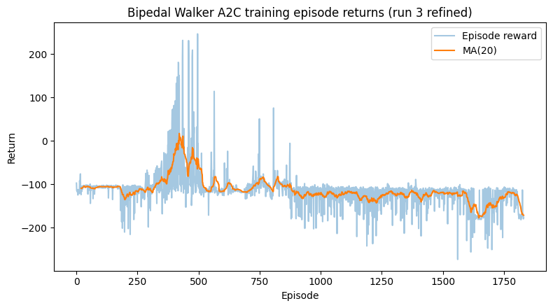

```
Saved plot to a3_part3_artifacts/bipedal_walker/run_3_bipedal/bipedal_train_rewards_v3.png
Saved Bipedal Walker A2C v3 weights to a3_part3_artifacts/bipedal_walker/run_3_bipedal/bipedal_a2c_weights_v3.pth
```

```python
# Third Bipedal Walker run with slight refinements over run 2
bipedal_run_name_v3 = "run_3_bipedal"
bipedal_run_dir_v3 = make_run_dir(BIPEDAL_ROOT, bipedal_run_name_v3)
print(f"Bipedal Walker v3 run directory: {bipedal_run_dir_v3}")

# Fresh model for the third run
bipedal_model_v3 = build_continuous_model_from_config(bipedal_cfg).to(device)

# Refined A2C hyperparameters for Bipedal Walker
bipedal_total_steps_v3 = 800_000       # more training than run 2
bipedal_rollout_len_v3 = 10           # keep shorter rollouts
bipedal_gamma_v3 = 0.99
bipedal_entropy_coef_v3 = 0.008       # slightly lower entropy
bipedal_value_coef_v3 = 0.5
bipedal_max_grad_norm_v3 = 0.25       # a bit tighter clipping
bipedal_lr_v3 = 2e-4                   # slightly smaller LR than run 2
bipedal_log_every_v3 = 20_000

bipedal_model_v3, bipedal_episode_returns_v3, bipedal_logs_v3 = train_a2c_single_env(
    env_id=BIPEDAL_ENV_ID,
    model=bipedal_model_v3,
    control_type="continuous",
    run_dir=bipedal_run_dir_v3,
    total_env_steps=bipedal_total_steps_v3,
    rollout_len=bipedal_rollout_len_v3,
    gamma=bipedal_gamma_v3,
    entropy_coef=bipedal_entropy_coef_v3,
    value_coef=bipedal_value_coef_v3,
    max_grad_norm=bipedal_max_grad_norm_v3,
    lr=bipedal_lr_v3,
    log_every=bipedal_log_every_v3,
)

# Plot training rewards for v3
plot_rewards(
    rewards=bipedal_episode_returns_v3,
    run_dir=bipedal_run_dir_v3,
    filename="bipedal_train_rewards_v3.png",
    title="Bipedal Walker A2C training episode returns (run 3 refined)",
    ma_window=20,
)

# Save v3 model weights
bipedal_weights_path_v3 = os.path.join(bipedal_run_dir_v3, "bipedal_a2c_weights_v3.pth")
torch.save(bipedal_model_v3.state_dict(), bipedal_weights_path_v3)
print(f"Saved Bipedal Walker A2C v3 weights to {bipedal_weights_path_v3}")
```

## 15. Bipedal Walker greedy evaluation (Run#2)

This cell evaluates the tuned Bipedal Walker agent from run 2 in greedy mode using the shared evaluation and plotting helpers. A fresh evaluation environment is created the actor critic model selects greedy actions for a fixed number of episodes and the total reward per episode is recorded. The episode returns are then plotted and saved into the run 2 directory together with printed summary statistics so that the final performance can be compared against the earlier baseline.

```
Eval episode 1 return 206.48 steps 1529
Eval episode 2 return 198.97 steps 1600
Eval episode 3 return 209.83 steps 1487
Eval episode 4 return 203.44 steps 1570
Eval episode 5 return 204.03 steps 1553
Eval episode 6 return 203.67 steps 1555
Eval episode 7 return 203.23 steps 1563
Eval episode 8 return 203.76 steps 1558
Eval episode 9 return 206.46 steps 1528
Eval episode 10 return 207.99 steps 1512
Greedy evaluation mean 204.79  std 2.87
```

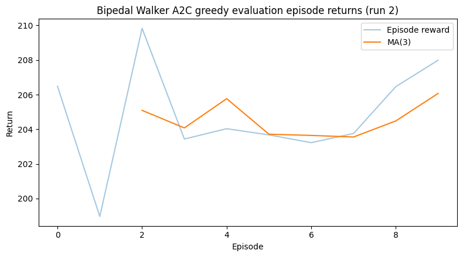

```
Saved plot to a3_part3_artifacts/bipedal_walker/run_2_bipedal/bipedal_eval_rewards_v2.png
Bipedal Walker run 2 greedy evaluation returns: [206.4808769330848, 198.9654706181027, 209.83059835142922, 203.43723478447646, 204.03332096268423, 203.67499424051493, 203.22810434247367, 203.75654550967738, 206.4631777908653, 207.99023681599647]
Mean return 204.79  Std 2.87
```

```python
# Number of greedy evaluation episodes for Bipedal Walker run 2
bipedal_eval_episodes_v2 = 10

# Reload the tuned weights
if not os.path.exists(bipedal_weights_path_v2):
    raise FileNotFoundError(f"Trained weights not found at {bipedal_weights_path_v2}")

bipedal_model_v2 = build_continuous_model_from_config(bipedal_cfg).to(device)
bipedal_model_v2.load_state_dict(torch.load(bipedal_weights_path_v2, map_location=device))

# Run greedy evaluation
bipedal_eval_returns_v2 = evaluate_greedy(
    env_id=BIPEDAL_ENV_ID,
    model=bipedal_model_v2,
    control_type="continuous",
    n_episodes=bipedal_eval_episodes_v2,
    run_dir=bipedal_run_dir_v2,
)

# Plot evaluation rewards
plot_rewards(
    rewards=bipedal_eval_returns_v2,
    run_dir=bipedal_run_dir_v2,
    filename="bipedal_eval_rewards_v2.png",
    title="Bipedal Walker A2C greedy evaluation episode returns (run 2)",
    ma_window=3,
)

print("Bipedal Walker run 2 greedy evaluation returns:", bipedal_eval_returns_v2)
print(f"Mean return {np.mean(bipedal_eval_returns_v2):.2f}  Std {np.std(bipedal_eval_returns_v2):.2f}")
```

## 16. Bipedal Walker greedy video recording (Run#2)

This cell records a single greedy evaluation episode for the tuned Bipedal Walker agent from run 2 and writes the video file into the videos subfolder of the run directory. The total reward and number of steps for the recorded episode are printed.

```python
# Record one greedy episode for Bipedal Walker run 2
bipedal_video_return_v2, bipedal_video_steps_v2 = record_one_greedy_episode(
    env_id=BIPEDAL_ENV_ID,
    model=bipedal_model_v2,
    control_type="continuous",
    run_dir=bipedal_run_dir_v2,
    max_steps=None,  # env time limit
)

print(
    f"Bipedal Walker run 2 video episode return {bipedal_video_return_v2:.2f} "
    f"steps {bipedal_video_steps_v2}"
)
print("Video saved under:", os.path.join(bipedal_run_dir_v2, "videos"))
```

```
Recorded greedy episode return 206.48 steps 1529 into a3_part3_artifacts/bipedal_walker/run_2_bipedal/videos
Bipedal Walker run 2 video episode return 206.48 steps 1529
Video saved under: a3_part3_artifacts/bipedal_walker/run_2_bipedal/videos
```